# Ford GoBike System - Data Findings

### by (Chinni Venkata Raju Koviri)

## Preliminary Wrangling

- Here we'll deal with Bay Wheels's trip data Each trip is anonymized and includes:
- Trip Duration (seconds)
- Start Time and Date
- End Time and Date
- Start Station ID
- Start Station Name
- Start Station Latitude
- Start Station Longitude
- End Station ID
- End Station Name
- End Station Latitude
- End Station Longitude
- Bike ID
- User Type (Subscriber or Customer – “Subscriber” = Member or “Customer” = Casual)
- member_birth_year
- member_gender
- bike_share_for_all_trip

> source : https://www.lyft.com/bikes/bay-wheels/system-data

```python
# import all packages and set plots to be embedded inline
import numpy as np
import pandas as pd
import matplotlib.pyplot as plt
import os
import geopandas
import seaborn as sns
import zipfile as zfile
import requests
import missingno as ms
import datetime
%matplotlib inline

import warnings
warnings.simplefilter("ignore")
```

# Data Wrangling

## Data Gathering

```python
# downloading the zip files 2018 jan, feb, march data from source link
dataset_year = ["201801","201802","201803"]
if not os.path.exists("source_file"):
        os.makedirs("source_file")
for year in dataset_year:
    response = requests.get(f"https://s3.amazonaws.com/fordgobike-data/{year}-fordgobike-tripdata.csv.zip")
    with open(f"source_file/{year}.csv.zip", mode = "wb") as file:
        file.write(response.content)
```

```python
# UnZip the data
files = list(os.listdir("./source_file"))
for file in files:
    if ".zip" in file:
        with zfile.ZipFile(f"./source_file/{file}",'r') as zipfiles:
            zipfiles.extractall("./")
```

## Assessing Data

```python
# Joining the data
df1 =  pd.read_csv("201801-fordgobike-tripdata.csv", low_memory=False)
df2 =  pd.read_csv("201802-fordgobike-tripdata.csv", low_memory=False)
df3 =  pd.read_csv("201803-fordgobike-tripdata.csv", low_memory=False)
df = pd.concat([df1,df2,df3])
df
```

|  | duration_sec | start_time | end_time | start_station_id | start_station_name | start_station_latitude | start_station_longitude | end_station_id | end_station_name | end_station_latitude | end_station_longitude | bike_id | user_type | member_birth_year | member_gender | bike_share_for_all_trip |
| --- | --- | --- | --- | --- | --- | --- | --- | --- | --- | --- | --- | --- | --- | --- | --- | --- |
| 0 | 75284 | 2018-01-31 22:52:35.2390 | 2018-02-01 19:47:19.8240 | 120 | Mission Dolores Park | 37.761420 | -122.426435 | 285 | Webster St at O'Farrell St | 37.783521 | -122.431158 | 2765 | Subscriber | 1986.0 | Male | No |
| 1 | 85422 | 2018-01-31 16:13:34.3510 | 2018-02-01 15:57:17.3100 | 15 | San Francisco Ferry Building (Harry Bridges Pl... | 37.795392 | -122.394203 | 15 | San Francisco Ferry Building (Harry Bridges Pl... | 37.795392 | -122.394203 | 2815 | Customer | NaN | NaN | No |
| 2 | 71576 | 2018-01-31 14:23:55.8890 | 2018-02-01 10:16:52.1160 | 304 | Jackson St at 5th St | 37.348759 | -121.894798 | 296 | 5th St at Virginia St | 37.325998 | -121.877120 | 3039 | Customer | 1996.0 | Male | No |
| 3 | 61076 | 2018-01-31 14:53:23.5620 | 2018-02-01 07:51:20.5000 | 75 | Market St at Franklin St | 37.773793 | -122.421239 | 47 | 4th St at Harrison St | 37.780955 | -122.399749 | 321 | Customer | NaN | NaN | No |
| 4 | 39966 | 2018-01-31 19:52:24.6670 | 2018-02-01 06:58:31.0530 | 74 | Laguna St at Hayes St | 37.776435 | -122.426244 | 19 | Post St at Kearny St | 37.788975 | -122.403452 | 617 | Subscriber | 1991.0 | Male | No |
| ... | ... | ... | ... | ... | ... | ... | ... | ... | ... | ... | ... | ... | ... | ... | ... | ... |
| 111377 | 471 | 2018-03-01 00:28:29.1730 | 2018-03-01 00:36:20.9280 | 180 | Telegraph Ave at 23rd St | 37.812678 | -122.268773 | 202 | Washington St at 8th St | 37.800754 | -122.274894 | 269 | Subscriber | 1970.0 | Male | Yes |
| 111378 | 285 | 2018-03-01 00:17:32.9500 | 2018-03-01 00:22:18.1560 | 183 | Telegraph Ave at 19th St | 37.808702 | -122.269927 | 195 | Bay Pl at Vernon St | 37.812314 | -122.260779 | 302 | Subscriber | 1971.0 | Male | No |
| 111379 | 408 | 2018-03-01 00:13:37.1640 | 2018-03-01 00:20:25.6830 | 27 | Beale St at Harrison St | 37.788059 | -122.391865 | 11 | Davis St at Jackson St | 37.797280 | -122.398436 | 1060 | Customer | 1998.0 | Male | No |
| 111380 | 368 | 2018-03-01 00:14:14.4590 | 2018-03-01 00:20:22.5140 | 27 | Beale St at Harrison St | 37.788059 | -122.391865 | 11 | Davis St at Jackson St | 37.797280 | -122.398436 | 3040 | Customer | 1996.0 | Male | No |
| 111381 | 164 | 2018-03-01 00:13:31.0810 | 2018-03-01 00:16:15.5200 | 240 | Haste St at Telegraph Ave | 37.866043 | -122.258804 | 266 | Parker St at Fulton St | 37.862464 | -122.264791 | 3693 | Subscriber | 1996.0 | Male | No |

312902 rows × 16 columns

## Storing Data

```python
df.to_csv("Gathereddata.csv")
```

## Data OverView

```python
# reading the csv file as data frame
df = pd.read_csv("Gathereddata.csv")
print("Sample data")
df.sample(5)
```

```
Sample data
```

|  | Unnamed: 0 | duration_sec | start_time | end_time | start_station_id | start_station_name | start_station_latitude | start_station_longitude | end_station_id | end_station_name | end_station_latitude | end_station_longitude | bike_id | user_type | member_birth_year | member_gender | bike_share_for_all_trip |
| --- | --- | --- | --- | --- | --- | --- | --- | --- | --- | --- | --- | --- | --- | --- | --- | --- | --- |
| 271291 | 69771 | 416 | 2018-03-13 15:15:06.0370 | 2018-03-13 15:22:02.6270 | 160 | West Oakland BART Station | 37.805318 | -122.294837 | 218 | DeFremery Park | 37.812331 | -122.285171 | 307 | Subscriber | 1988.0 | Female | Yes |
| 92494 | 92494 | 308 | 2018-01-02 09:29:41.9170 | 2018-01-02 09:34:50.9000 | 67 | San Francisco Caltrain Station 2 (Townsend St... | 37.776639 | -122.395526 | 79 | 7th St at Brannan St | 37.773492 | -122.403672 | 3681 | Subscriber | 1975.0 | Male | No |
| 5850 | 5850 | 389 | 2018-01-30 17:37:10.2560 | 2018-01-30 17:43:39.5540 | 79 | 7th St at Brannan St | 37.773492 | -122.403672 | 67 | San Francisco Caltrain Station 2 (Townsend St... | 37.776639 | -122.395526 | 1627 | Subscriber | 1993.0 | Male | No |
| 250756 | 49236 | 774 | 2018-03-19 17:22:26.8230 | 2018-03-19 17:35:21.1830 | 108 | 16th St Mission BART | 37.764710 | -122.419957 | 118 | Eureka Valley Recreation Center | 37.759177 | -122.436943 | 2664 | Subscriber | 1960.0 | Male | No |
| 52765 | 52765 | 513 | 2018-01-16 21:29:33.0990 | 2018-01-16 21:38:07.0960 | 182 | 19th Street BART Station | 37.809013 | -122.268247 | 195 | Bay Pl at Vernon St | 37.812314 | -122.260779 | 2051 | Subscriber | 1980.0 | Female | No |

```python
#dropping garbage columns
df.drop(columns ={"Unnamed: 0"},inplace = True)
```

```python
print(f"shape of the dataset {df.shape}")
```

```
shape of the dataset (312902, 16)
```

```python
print("data overview")
df.info()
```

```
data overview
<class 'pandas.core.frame.DataFrame'>
RangeIndex: 312902 entries, 0 to 312901
Data columns (total 16 columns):
 #   Column                   Non-Null Count   Dtype
---  ------                   --------------   -----
 0   duration_sec             312902 non-null  int64
 1   start_time               312902 non-null  object
 2   end_time                 312902 non-null  object
 3   start_station_id         312902 non-null  int64
 4   start_station_name       312902 non-null  object
 5   start_station_latitude   312902 non-null  float64
 6   start_station_longitude  312902 non-null  float64
 7   end_station_id           312902 non-null  int64
 8   end_station_name         312902 non-null  object
 9   end_station_latitude     312902 non-null  float64
 10  end_station_longitude    312902 non-null  float64
 11  bike_id                  312902 non-null  int64
 12  user_type                312902 non-null  object
 13  member_birth_year        287936 non-null  float64
 14  member_gender            288048 non-null  object
 15  bike_share_for_all_trip  312902 non-null  object
dtypes: float64(5), int64(4), object(7)
memory usage: 38.2+ MB
```

```python
print("data statistics")
df.describe()
```

```
data statistics
```

|  | duration_sec | start_station_id | start_station_latitude | start_station_longitude | end_station_id | end_station_latitude | end_station_longitude | bike_id | member_birth_year |
| --- | --- | --- | --- | --- | --- | --- | --- | --- | --- |
| count | 312902.000000 | 312902.000000 | 312902.000000 | 312902.000000 | 312902.000000 | 312902.000000 | 312902.000000 | 312902.000000 | 287936.000000 |
| mean | 873.469128 | 110.523288 | 37.767406 | -122.353051 | 108.147915 | 37.767568 | -122.352232 | 2022.359921 | 1981.493888 |
| std | 2581.448666 | 93.195184 | 0.101100 | 0.119657 | 92.685325 | 0.100941 | 0.118997 | 1090.904418 | 10.760571 |
| min | 61.000000 | 3.000000 | 37.312854 | -122.444293 | 3.000000 | 37.312854 | -122.444293 | 11.000000 | 1900.000000 |
| 25% | 355.000000 | 30.000000 | 37.771058 | -122.411738 | 29.000000 | 37.771662 | -122.410662 | 1112.000000 | 1976.000000 |
| 50% | 553.000000 | 81.000000 | 37.781383 | -122.398436 | 81.000000 | 37.781650 | -122.397405 | 2116.000000 | 1984.000000 |
| 75% | 856.000000 | 176.000000 | 37.795392 | -122.294837 | 176.000000 | 37.795393 | -122.294837 | 2990.000000 | 1989.000000 |
| max | 86366.000000 | 343.000000 | 37.880222 | -121.874119 | 343.000000 | 37.880222 | -121.874119 | 3756.000000 | 2000.000000 |

```python
print("dulipcated values count",df.duplicated().sum())
```

```
dulipcated values count 0
```

```python
print("null values count",df.isnull().sum())
```

```
null values count duration_sec                   0
start_time                     0
end_time                       0
start_station_id               0
start_station_name             0
start_station_latitude         0
start_station_longitude        0
end_station_id                 0
end_station_name               0
end_station_latitude           0
end_station_longitude          0
bike_id                        0
user_type                      0
member_birth_year          24966
member_gender              24854
bike_share_for_all_trip        0
dtype: int64
```

# Data Overview Summary

### Quality

- There are missing values member_birth_year and member_gender columns which needs to be fixed
- Wrong data type for the columns 'start_time','end_time' and 'member_birth_year'

### Tidiness

- No Tidiness issues

## Cleaning

### Convert dtypes of the columns

- 'start_time'to datetime
- 'end_time' to datetime
- 'member_birth_year' to int

```python
# dtype conversion code
df["start_time"] = pd.to_datetime(df.start_time)
df["end_time"] = pd.to_datetime(df.end_time)
df["member_birth_year"]= df.member_birth_year.round().astype('Int64')
```

```python
#test
df[["start_time","end_time","member_birth_year"]].dtypes
```

```
start_time           datetime64[ns]
end_time             datetime64[ns]
member_birth_year             Int64
dtype: object
```

#### Treating missing values

- Fill the missing values with mean of the column

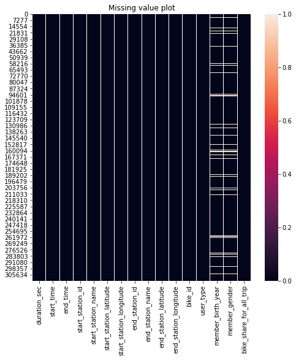

```python
#plot to find the null values
plt.figure(figsize =(8,8))
plt.title("Missing value plot")
plt.xlabel("columns")
plt.ylabel("row numbers")
sns.heatmap(df.isnull());
```

#### Filling null values

As the member_birth_year is continues data we can replace the null values with mean and the null values of member_gender with "No data"

```python
#getting mean value year
df["member_birth_year"].mean().round()
```

```
1981.0
```

```python
# fillling null values
df["member_birth_year"].fillna(df["member_birth_year"].mean().round(),inplace = True)
df["member_gender"].fillna("No data",inplace = True)
```

```python
#test
df.isnull().sum()
```

```
duration_sec               0
start_time                 0
end_time                   0
start_station_id           0
start_station_name         0
start_station_latitude     0
start_station_longitude    0
end_station_id             0
end_station_name           0
end_station_latitude       0
end_station_longitude      0
bike_id                    0
user_type                  0
member_birth_year          0
member_gender              0
bike_share_for_all_trip    0
dtype: int64
```

## Extracting New Columns

- Day, month column using Start time and end time
- Creating new column by converting duration seconds to mintues
- Age of member using member birth year
- Distance using longitude and latitude

```python
#extracting day column
df["start_day"]=df['start_time'].dt.day_name()
df["start_month"]=df['start_time'].dt.month_name()
df["end_day"]=df['end_time'].dt.day_name()
df["end_month"]=df['end_time'].dt.month_name()
```

```python
#test
df[["start_day","start_month","end_day","end_month"]]
```

|  | start_day | start_month | end_day | end_month |
| --- | --- | --- | --- | --- |
| 0 | Wednesday | January | Thursday | February |
| 1 | Wednesday | January | Thursday | February |
| 2 | Wednesday | January | Thursday | February |
| 3 | Wednesday | January | Thursday | February |
| 4 | Wednesday | January | Thursday | February |
| ... | ... | ... | ... | ... |
| 312897 | Thursday | March | Thursday | March |
| 312898 | Thursday | March | Thursday | March |
| 312899 | Thursday | March | Thursday | March |
| 312900 | Thursday | March | Thursday | March |
| 312901 | Thursday | March | Thursday | March |

312902 rows × 4 columns

#### Extracting minitues from duration seconds

```python
# converting seconds to minitues
df['duration_min'] = (df['duration_sec']/60).astype(int)
```

```python
#test
df['duration_min']
```

```
0         1254
1         1423
2         1192
3         1017
4          666
          ...
312897       7
312898       4
312899       6
312900       6
312901       2
Name: duration_min, Length: 312902, dtype: int64
```

#### Extracting age from duration member year

```python
# calculating Age from member birth year
df['member_age'] = 2020 - df['member_birth_year']
```

```python
#test
df['member_age']
```

```
0         34
1         39
2         24
3         39
4         29
          ..
312897    50
312898    49
312899    22
312900    24
312901    24
Name: member_age, Length: 312902, dtype: Int64
```

```python
df['member_age'].describe()
```

```
count    312902.000000
mean         38.545519
std          10.323229
min          20.000000
25%          31.000000
50%          37.000000
75%          43.000000
max         120.000000
Name: member_age, dtype: float64
```

```python
df.info()
```

```
<class 'pandas.core.frame.DataFrame'>
RangeIndex: 312902 entries, 0 to 312901
Data columns (total 22 columns):
 #   Column                   Non-Null Count   Dtype
---  ------                   --------------   -----
 0   duration_sec             312902 non-null  int64
 1   start_time               312902 non-null  datetime64[ns]
 2   end_time                 312902 non-null  datetime64[ns]
 3   start_station_id         312902 non-null  int64
 4   start_station_name       312902 non-null  object
 5   start_station_latitude   312902 non-null  float64
 6   start_station_longitude  312902 non-null  float64
 7   end_station_id           312902 non-null  int64
 8   end_station_name         312902 non-null  object
 9   end_station_latitude     312902 non-null  float64
 10  end_station_longitude    312902 non-null  float64
 11  bike_id                  312902 non-null  int64
 12  user_type                312902 non-null  object
 13  member_birth_year        312902 non-null  Int64
 14  member_gender            312902 non-null  object
 15  bike_share_for_all_trip  312902 non-null  object
 16  start_day                312902 non-null  object
 17  start_month              312902 non-null  object
 18  end_day                  312902 non-null  object
 19  end_month                312902 non-null  object
 20  duration_min             312902 non-null  int64
 21  member_age               312902 non-null  Int64
dtypes: Int64(2), datetime64[ns](2), float64(4), int64(5), object(9)
memory usage: 53.1+ MB
```

```python
# code from https://stackoverflow.com/questions/40452759/pandas-latitude-longitude-to-distance-between-successive-rows
lat1 = df.start_station_latitude
lon1= df.start_station_longitude
lat2=   df.end_station_latitude
lon2 = df.end_station_longitude
earth_radius=6371
lat1, lon1, lat2, lon2 = np.radians([lat1, lon1, lat2, lon2])
a = np.sin((lat2-lat1)/2.0)**2 + \
np.cos(lat1) * np.cos(lat2) * np.sin((lon2-lon1)/2.0)**2
df['dist'] =  earth_radius * 2 * np.arcsin(np.sqrt(a))
```

```python
df
```

|  | duration_sec | start_time | end_time | start_station_id | start_station_name | start_station_latitude | start_station_longitude | end_station_id | end_station_name | end_station_latitude | ... | member_birth_year | member_gender | bike_share_for_all_trip | start_day | start_month | end_day | end_month | duration_min | member_age | dist |
| --- | --- | --- | --- | --- | --- | --- | --- | --- | --- | --- | --- | --- | --- | --- | --- | --- | --- | --- | --- | --- | --- |
| 0 | 75284 | 2018-01-31 22:52:35.239 | 2018-02-01 19:47:19.824 | 120 | Mission Dolores Park | 37.761420 | -122.426435 | 285 | Webster St at O'Farrell St | 37.783521 | ... | 1986 | Male | No | Wednesday | January | Thursday | February | 1254 | 34 | 2.492254 |
| 1 | 85422 | 2018-01-31 16:13:34.351 | 2018-02-01 15:57:17.310 | 15 | San Francisco Ferry Building (Harry Bridges Pl... | 37.795392 | -122.394203 | 15 | San Francisco Ferry Building (Harry Bridges Pl... | 37.795392 | ... | 1981 | No data | No | Wednesday | January | Thursday | February | 1423 | 39 | 0.000000 |
| 2 | 71576 | 2018-01-31 14:23:55.889 | 2018-02-01 10:16:52.116 | 304 | Jackson St at 5th St | 37.348759 | -121.894798 | 296 | 5th St at Virginia St | 37.325998 | ... | 1996 | Male | No | Wednesday | January | Thursday | February | 1192 | 24 | 2.974502 |
| 3 | 61076 | 2018-01-31 14:53:23.562 | 2018-02-01 07:51:20.500 | 75 | Market St at Franklin St | 37.773793 | -122.421239 | 47 | 4th St at Harrison St | 37.780955 | ... | 1981 | No data | No | Wednesday | January | Thursday | February | 1017 | 39 | 2.049710 |
| 4 | 39966 | 2018-01-31 19:52:24.667 | 2018-02-01 06:58:31.053 | 74 | Laguna St at Hayes St | 37.776435 | -122.426244 | 19 | Post St at Kearny St | 37.788975 | ... | 1991 | Male | No | Wednesday | January | Thursday | February | 666 | 29 | 2.440571 |
| ... | ... | ... | ... | ... | ... | ... | ... | ... | ... | ... | ... | ... | ... | ... | ... | ... | ... | ... | ... | ... | ... |
| 312897 | 471 | 2018-03-01 00:28:29.173 | 2018-03-01 00:36:20.928 | 180 | Telegraph Ave at 23rd St | 37.812678 | -122.268773 | 202 | Washington St at 8th St | 37.800754 | ... | 1970 | Male | Yes | Thursday | March | Thursday | March | 7 | 50 | 1.430801 |
| 312898 | 285 | 2018-03-01 00:17:32.950 | 2018-03-01 00:22:18.156 | 183 | Telegraph Ave at 19th St | 37.808702 | -122.269927 | 195 | Bay Pl at Vernon St | 37.812314 | ... | 1971 | Male | No | Thursday | March | Thursday | March | 4 | 49 | 0.898458 |
| 312899 | 408 | 2018-03-01 00:13:37.164 | 2018-03-01 00:20:25.683 | 27 | Beale St at Harrison St | 37.788059 | -122.391865 | 11 | Davis St at Jackson St | 37.797280 | ... | 1998 | Male | No | Thursday | March | Thursday | March | 6 | 22 | 1.176704 |
| 312900 | 368 | 2018-03-01 00:14:14.459 | 2018-03-01 00:20:22.514 | 27 | Beale St at Harrison St | 37.788059 | -122.391865 | 11 | Davis St at Jackson St | 37.797280 | ... | 1996 | Male | No | Thursday | March | Thursday | March | 6 | 24 | 1.176704 |
| 312901 | 164 | 2018-03-01 00:13:31.081 | 2018-03-01 00:16:15.520 | 240 | Haste St at Telegraph Ave | 37.866043 | -122.258804 | 266 | Parker St at Fulton St | 37.862464 | ... | 1996 | Male | No | Thursday | March | Thursday | March | 2 | 24 | 0.659200 |

312902 rows × 23 columns

```python
df["Trip_Start_hour"] = df["start_time"].dt.hour
```

```python
df.head(2)
```

|  | duration_sec | start_time | end_time | start_station_id | start_station_name | start_station_latitude | start_station_longitude | end_station_id | end_station_name | end_station_latitude | ... | member_gender | bike_share_for_all_trip | start_day | start_month | end_day | end_month | duration_min | member_age | dist | Trip_Start_hour |
| --- | --- | --- | --- | --- | --- | --- | --- | --- | --- | --- | --- | --- | --- | --- | --- | --- | --- | --- | --- | --- | --- |
| 0 | 75284 | 2018-01-31 22:52:35.239 | 2018-02-01 19:47:19.824 | 120 | Mission Dolores Park | 37.761420 | -122.426435 | 285 | Webster St at O'Farrell St | 37.783521 | ... | Male | No | Wednesday | January | Thursday | February | 1254 | 34 | 2.492254 | 22 |
| 1 | 85422 | 2018-01-31 16:13:34.351 | 2018-02-01 15:57:17.310 | 15 | San Francisco Ferry Building (Harry Bridges Pl... | 37.795392 | -122.394203 | 15 | San Francisco Ferry Building (Harry Bridges Pl... | 37.795392 | ... | No data | No | Wednesday | January | Thursday | February | 1423 | 39 | 0.000000 | 16 |

2 rows × 24 columns

```python
df.shape
```

```
(312902, 24)
```

```python
df.dtypes
```

```
duration_sec                        int64
start_time                 datetime64[ns]
end_time                   datetime64[ns]
start_station_id                    int64
start_station_name                 object
start_station_latitude            float64
start_station_longitude           float64
end_station_id                      int64
end_station_name                   object
end_station_latitude              float64
end_station_longitude             float64
bike_id                             int64
user_type                          object
member_birth_year                   Int64
member_gender                      object
bike_share_for_all_trip            object
start_day                          object
start_month                        object
end_day                            object
end_month                          object
duration_min                        int64
member_age                          Int64
dist                              float64
Trip_Start_hour                     int64
dtype: object
```

### Top ten Start stations

```python
df["start_station_name"].value_counts()[:10]
```

```
San Francisco Ferry Building (Harry Bridges Plaza)           7170
San Francisco Caltrain (Townsend St at 4th St)               7012
Berry St at 4th St                                           6550
Market St at 10th St                                         6432
The Embarcadero at Sansome St                                6004
San Francisco Caltrain Station 2  (Townsend St at 4th St)    5755
Montgomery St BART Station (Market St at 2nd St)             5352
Powell St BART Station (Market St at 4th St)                 5329
Howard St at Beale St                                        5076
Steuart St at Market St                                      4967
Name: start_station_name, dtype: int64
```

```python
df.to_csv("cleaneddata.csv")
```

```python
df = pd.read_csv("cleaneddata.csv")
```

### What is/are the main feature(s) of interest in your dataset?

- start_station_name object
- user_type object
- start_day object
- start_month object
- end_day object
- end_month object
- time datetime64[ns]
- duration_min int64
- member_age Int64
- dist float64

### What features in the dataset do you think will help support your investigation into your feature(s) of interest?

The above stated features helps us to investigate and draw some conclusions.

## Univariate Exploration

> In this section, we are going to investigate distributions of individual variables, unusual points or outliers and prepare the data to look at relationships between variables.

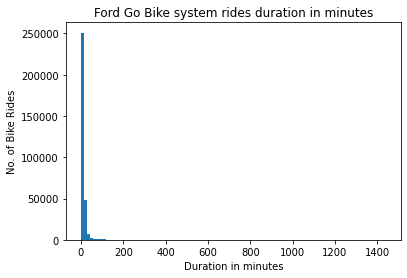

```python
plt.hist(df["duration_min"],bins =100)
plt.title("Ford Go Bike system rides duration in minutes")
plt.xlabel('Duration in minutes');
plt.ylabel('No. of Bike Rides');
```

Duration in mins data is right skewed beacuse of spread of data till 1400. We can consider the extreme data as outliers but there might be a chance of users who took trip for 1400miles or user may took the bike but didnt ride. So, we cannot consider this data as outliers.

### Binning Duration column

```python
df["duration_min"].describe()
```

```
count    312902.000000
mean         14.066222
std          43.023676
min           1.000000
25%           5.000000
50%           9.000000
75%          14.000000
max        1439.000000
Name: duration_min, dtype: float64
```

```python
bin_labels= ['below-10min', '10-30mins', '30-60mins', 'above60mins']
bins = [0,10,30,60,1439]
df["duration"] = pd.cut(df['duration_min'], bins,labels=bin_labels)
```

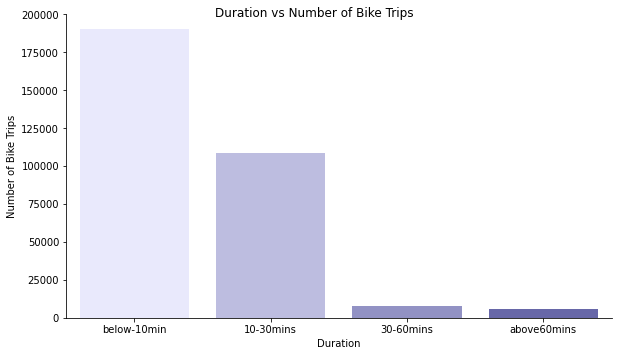

```python
chart = sns.catplot(data = df, x = 'duration', kind = 'count', aspect = 1.7,palette =sns.light_palette("navy"));
chart.set_axis_labels('Duration', 'Number of Bike Trips');
chart.fig.suptitle("Duration vs Number of Bike Trips ");
```

Fromt the above plot. It's clear that most of the rides are below 30mins in which most of them are below 10mins.

### Trip counts by day

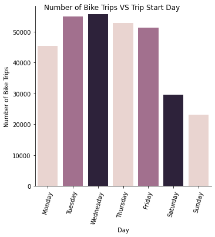

```python
# catplot using seaborn libraray for Trip counts by day
days = ['Monday', 'Tuesday', 'Wednesday', 'Thursday', 'Friday', 'Saturday', 'Sunday']
chart = sns.catplot(data=df, x='start_day', kind='count', order= days,palette = sns.cubehelix_palette(3));
chart.set_xticklabels(rotation=75);
chart.set_axis_labels('Day', 'Number of Bike Trips');
chart.fig.suptitle("Number of Bike Trips VS Trip Start Day");
```

Above plots gives information that most of the rides are on the week days.

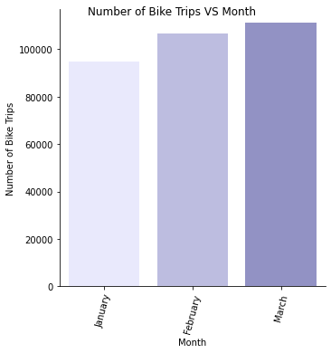

```python
chart = sns.catplot(data=df, x='start_month', kind='count',palette = sns.light_palette("navy"));
chart.set_xticklabels(rotation=75);
chart.set_axis_labels('Month', 'Number of Bike Trips');
chart.fig.suptitle("Number of Bike Trips VS Month");
```

### Distribution of member_age data

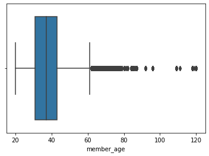

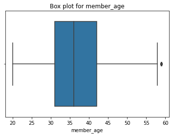

```python
#box plot
sns.boxplot(df["member_age"])
plt.show()
df_age = df[df["member_age"] < 60 ]
sns.boxplot(df_age["member_age"] )
plt.title("Box plot for member_age")
plt.xlabel("member_age");
plt.show()
```

The mean of member age if we remove outliers is around 37 and the range is 20 to 58 years.

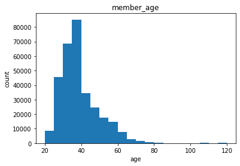

```python
#hist plot
plt.hist(data = df, x = 'member_age', bins = 20);
plt.title("member_age")
plt.xlabel("age")
plt.ylabel("count");
```

From the two plots we can say that there are some outliers in the member_age data. But the highest noted is 120, for this data point their might be a chance that a trip may be registred under a person who's age is 120. So, we cannnot consider this data as outlier without proper reason.

```python
bin_labels= ['20-30', '30-40', '40-60', 'above60 ']
bins = [20,30,40,60,120]
df["age_group"] = pd.cut(df['member_age'], bins,labels=bin_labels)
```

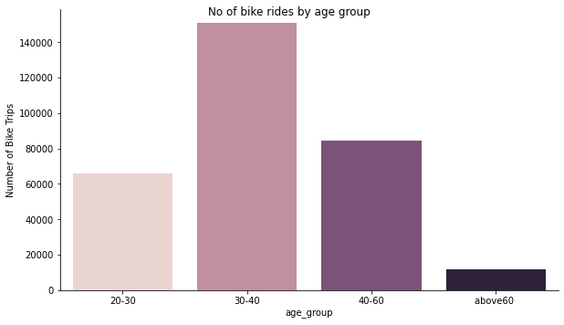

```python
chart = sns.catplot(data = df, x = 'age_group', kind = 'count', aspect = 1.7,palette = sns.cubehelix_palette(4));
chart.set_axis_labels('age_group', 'Number of Bike Trips')
chart.fig.suptitle("No of bike rides by age group");
```

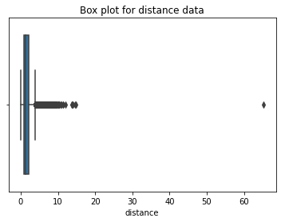

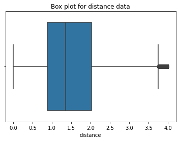

```python
#Box plot for distance
sns.boxplot(df["dist"])
plt.title("Box plot for distance data")
plt.xlabel("distance");
plt.show()
df_dist = df[df["dist"] < 4 ]
sns.boxplot(df_dist["dist"] )
plt.title("Box plot for distance data")
plt.xlabel("distance");
plt.show()
```

There is a extreme point that is 60+mines which is an outlier. but i leave this data point as it is for more research. The mean distance if we remove outliers is 1.5 and the range is 0 to 4km

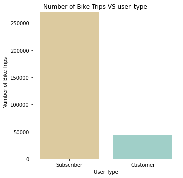

```python
# cat plot for user_type
chart = sns.catplot(data=df, x='user_type', kind='count',palette = sns.color_palette("BrBG", 2));
chart.set_axis_labels('User Type', 'Number of Bike Trips');
chart.fig.suptitle("Number of Bike Trips VS user_type");
```

Most of riders are taken by Subscribers

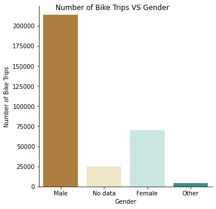

```python
# cat plot for member_gender
chart = sns.catplot(data=df, x='member_gender', kind='count',palette = sns.color_palette("BrBG", 4));
chart.set_axis_labels('Gender', 'Number of Bike Trips');
chart.fig.suptitle("Number of Bike Trips VS Gender");
```

Most of the rides are taken by male

### Discuss the distribution(s) of your variable(s) of interest. Were there any unusual points? Did you need to perform any transformations?

> The duration, distance and age have outliers. But without of proper reason we cannot remove these outliers as there is a possiblity of this data to exist.

### Of the features you investigated, were there any unusual distributions? Did you perform any operations on the data to tidy, adjust, or change the form of the data? If so, why did you do this?

> I did binning for duration column, age column for better understanding

## Bivariate Exploration

> In this section, we are going to investigate relationships between pairs of variables in our data.

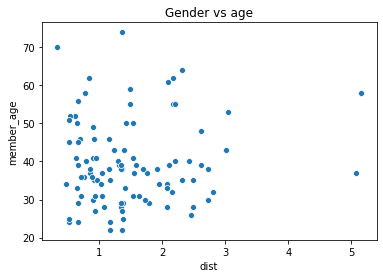

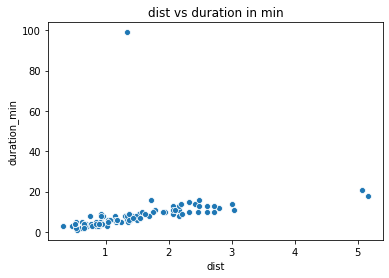

```python
df1000 = df.tail(100)
chart =sns.scatterplot(df1000["dist"],df1000["member_age"]);
plt.title("Gender vs age");
plt.show()
sns.scatterplot(df1000["dist"],df1000["duration_min"]);
plt.title("dist vs duration in min");
plt.show()
```

```python
df["start_month"].value_counts()
```

```
March       111382
February    106718
January      94802
Name: start_month, dtype: int64
```

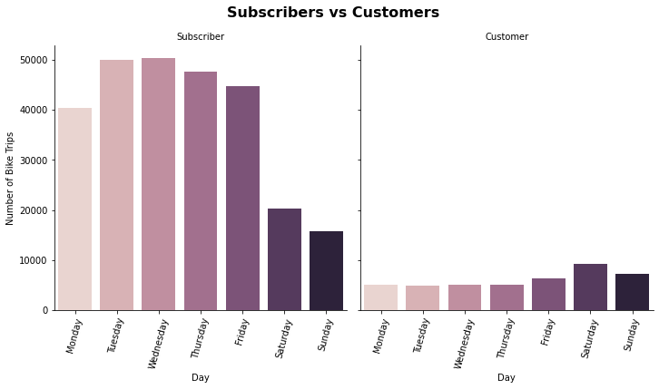

```python
#catplot for comparision between Users based on no.of trips taken per day
days = ['Monday', 'Tuesday', 'Wednesday', 'Thursday', 'Friday', 'Saturday', 'Sunday']
chart = sns.catplot(data=df, x='start_day', kind='count', col="user_type",order=days,palette = sns.cubehelix_palette(7));
chart.set_axis_labels("Day", "Number of Bike Trips");
chart.set_titles("{col_name}");
chart.fig.suptitle('Subscribers vs Customers ',  fontsize=16, fontweight='bold',y=1.05);
chart.set_xticklabels(rotation=75);
```

from comparision between Users based on no.of trips taken per day. Most of the rides are on weekdays and that too most of the users are Subscribers

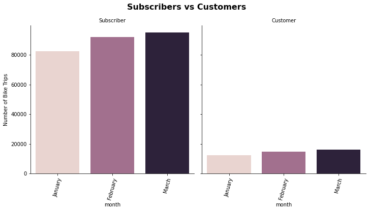

```python
#catplot for comparision between Users based on no.of trips taken per day
chart = sns.catplot(data=df, x='start_month', kind='count', col="user_type",palette = sns.cubehelix_palette(3));
chart.set_axis_labels("month", "Number of Bike Trips");
chart.set_titles("{col_name}");
chart.fig.suptitle('Subscribers vs Customers ',  fontsize=16, fontweight='bold',y=1.05);
chart.set_xticklabels(rotation=75);
```

From comparision between Users based on no.of trips taken per day. Most of the rides are in march month and that too most of the users are Subscribers

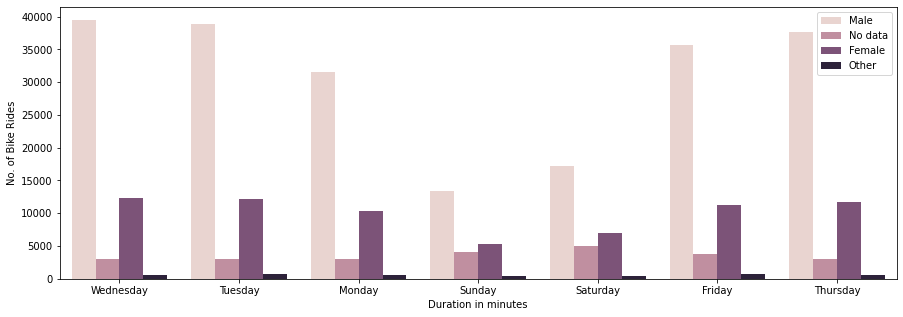

```python
# barplot for number of bike rides per day for different genders
plt.figure(figsize=(15,5))
sns.countplot(data=df, x='start_day', hue='member_gender',palette=sns.cubehelix_palette(4));
plt.xlabel('Duration in minutes');
plt.ylabel('No. of Bike Rides');
plt.legend(loc='best');
```

Most of the rides are taken by male gender and there is very low rides on weekends

### Talk about some of the relationships you observed in this part of the investigation. How did the feature(s) of interest vary with other features in the dataset?

> From Bivariate analysis. Most of the rides are taken by Subscribers, males and on weekdays.

## Multivariate Exploration

> Create plots of three or more variables to investigate your data even further.

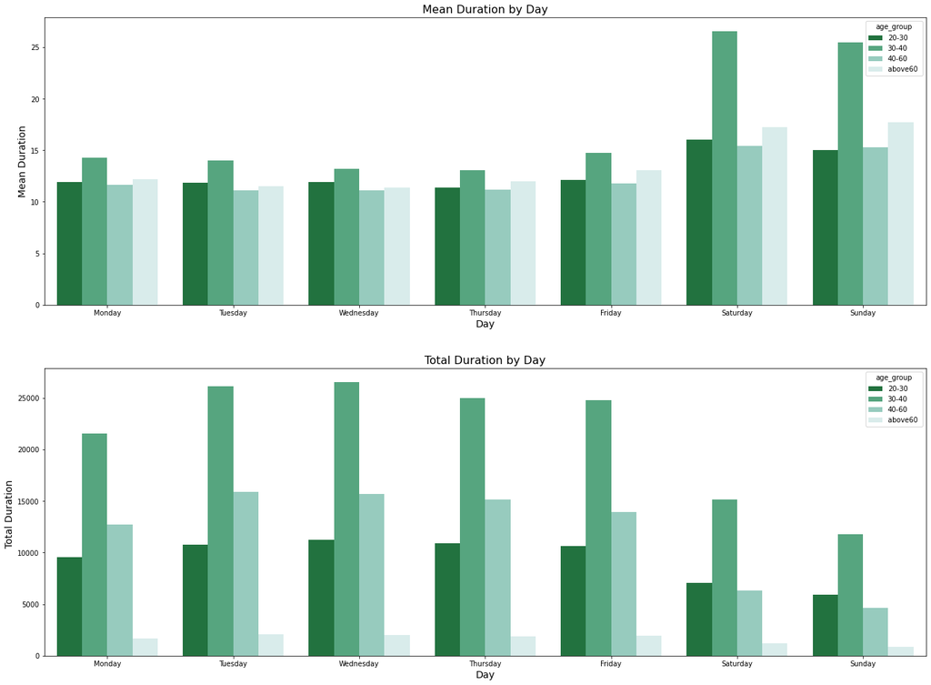

```python
# Bar plots to find the comparison between mean duration and Total duration grouped by age group and by days
days = ['Monday', 'Tuesday', 'Wednesday', 'Thursday', 'Friday', 'Saturday', 'Sunday']
fig, (ax1, ax2) = plt.subplots(2, 1, figsize=(20, 15))
fig.tight_layout(pad=7)
mean = df.groupby(['age_group', 'start_day'])
mean=mean.duration_min.mean()
mean=mean.reset_index()
sns.barplot(data=mean,x="start_day", y="duration_min", hue="age_group", ax=ax1,palette='BuGn_r',order = days)
ax1.set_xlabel('Day', fontsize=14);
ax1.set_ylabel('Mean Duration', fontsize=14);
ax1.set_title('Mean Duration by Day', fontsize=16);
sns.countplot( data=df, x="start_day", hue="age_group", ax=ax2,palette='BuGn_r',order = days)
ax2.set_xlabel('Day', fontsize=14);
ax2.set_ylabel('Total Duration ', fontsize=14);
ax2.set_title('Total Duration by Day', fontsize=16);
```

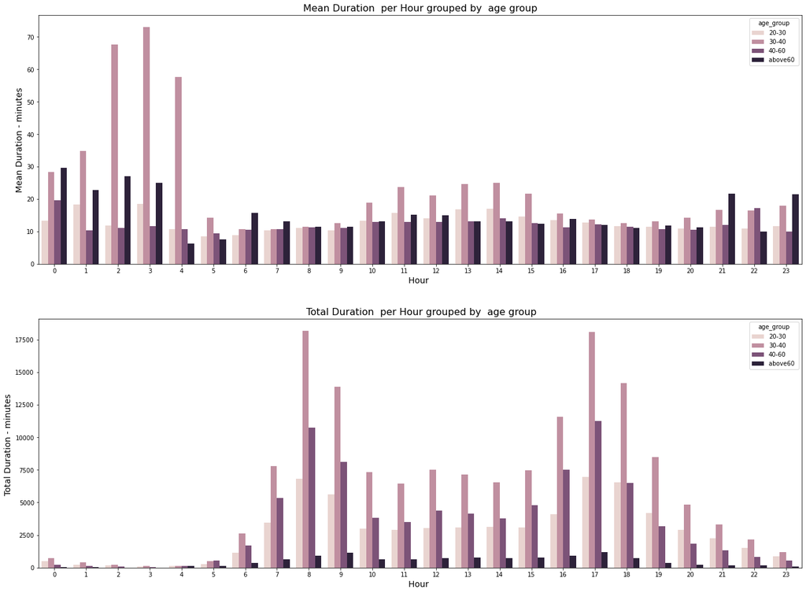

```python
# Bar plots to find the comparison between mean duration and Total duration grouped by age group and by hours
fig, (ax1, ax2) = plt.subplots(2, 1, figsize=(20, 15))
fig.tight_layout(pad=7)
mean = df.groupby(['age_group', 'Trip_Start_hour'])
mean=mean.duration_min.mean()
mean=mean.reset_index()
sns.barplot(data= mean,x="Trip_Start_hour", y="duration_min", hue="age_group", ax=ax1,palette=sns.cubehelix_palette(4))
ax1.set_xlabel('Hour ', fontsize=14);
ax1.set_ylabel('Mean Duration - minutes', fontsize=14);
ax1.set_title('Mean Duration  per Hour grouped by  age group', fontsize=16);
sns.countplot( data=df, x="Trip_Start_hour", hue="age_group", ax=ax2,palette=sns.cubehelix_palette(4))
ax2.set_xlabel('Hour ', fontsize=14);
ax2.set_ylabel('Total Duration - minutes ', fontsize=14);
ax2.set_title(' Total Duration  per Hour grouped by  age group', fontsize=16,);
```

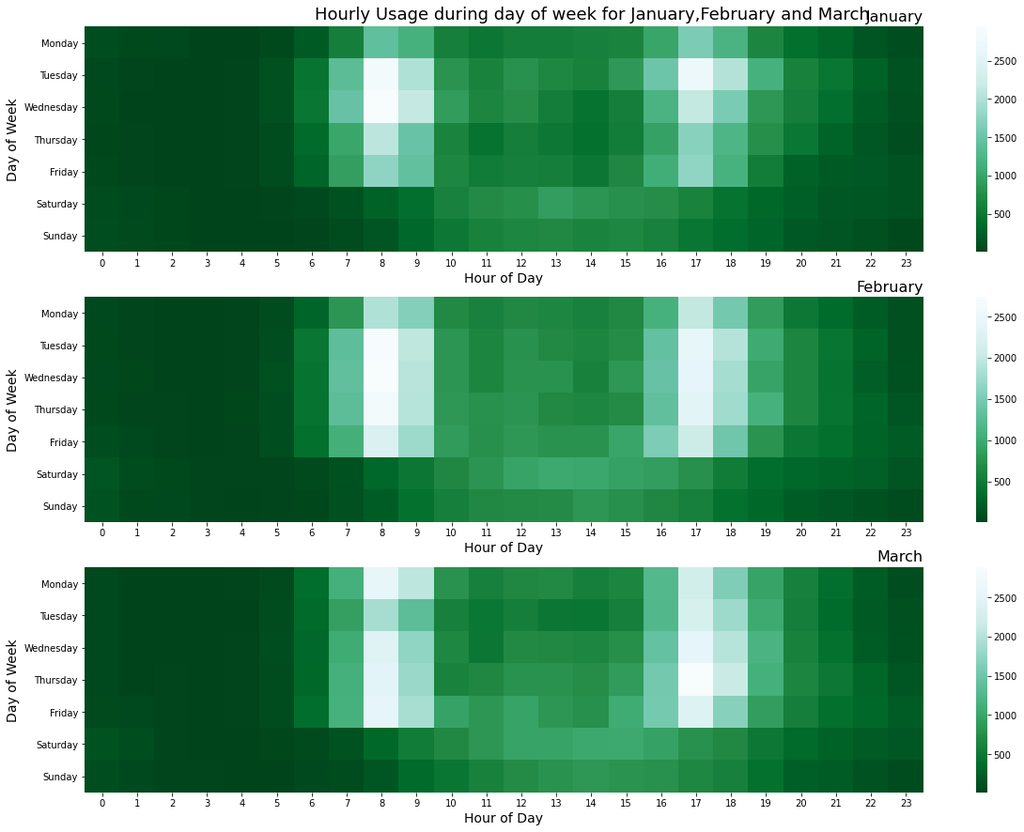

```python
# Hourly Usage during day of week for January,February and March
df_jan = df.query("start_month == 'January'")
df_feb = df.query("start_month == 'February'")
df_march = df.query("start_month == 'March'")
days = ['Monday', 'Tuesday', 'Wednesday', 'Thursday', 'Friday', 'Saturday', 'Sunday']
df_jan = df_jan.groupby(['start_day', 'Trip_Start_hour']).size()
df_jan = df_jan.reset_index(name='count')
df_jan = df_jan.pivot(index='start_day', columns='Trip_Start_hour', values='count')

df_feb = df_feb.groupby(['start_day', 'Trip_Start_hour']).size()
df_feb = df_feb.reset_index(name='count')
df_feb = df_feb.pivot(index='start_day', columns='Trip_Start_hour', values='count')

df_march = df_march.groupby(['start_day', 'Trip_Start_hour']).size()
df_march = df_march.reset_index(name='count')
df_march = df_march.pivot(index='start_day', columns='Trip_Start_hour', values='count')

fig, (ax1, ax2,ax3) = plt.subplots(3, 1, figsize=(20, 15))
plt.suptitle("Hourly Usage during day of week for January,February and March", fontsize = 18,y=0.9)
sns.heatmap(df_jan.reindex(days), cmap='BuGn_r', ax=ax1);
ax1.set_title("January", loc='right', fontsize = 16);
ax1.set_xlabel("Hour of Day", fontsize = 14);
ax1.set_ylabel("Day of Week", fontsize = 14);

sns.heatmap(df_feb.reindex(days), cmap='BuGn_r', ax=ax2);
ax2.set_title("February", loc='right', fontsize = 16);
ax2.set_xlabel("Hour of Day", fontsize = 14);
ax2.set_ylabel("Day of Week", fontsize = 14);

sns.heatmap(df_march.reindex(days), cmap='BuGn_r', ax=ax3);
ax3.set_title("March", loc='right', fontsize = 16);
ax3.set_xlabel("Hour of Day", fontsize = 14);
ax3.set_ylabel("Day of Week", fontsize = 14);
```

### Were there any interesting or surprising interactions between features?

> There is an intresting insight that in weekends the mean duration high and the total duration is high in weekdays. Total duration is high in the period 8 to 20 hour and mean duration is high in the period 0 to 5 hour . The reason is most the even the rides on weekends is less but the average duration of rides is high.

# Summary:

  > Francisco Ferry Building (Harry Bridges Plaza)  
  > San Francisco Caltrain (Townsend St at 4th St)  
  > Berry St at 4th St  
  > Market St at 10th St  
  > The Embarcadero at Sansome St  
  > San Francisco Caltrain Station 2 (Townsend St at 4th St)  
  > Montgomery St BART Station (Market St at 2nd St)  
  > Powell St BART Station (Market St at 4th St)  
  > Howard St at Beale St  
  > Steuart St at Market St

#### The company should provide some offers for below catergories to increase their business.

- for female customers
- on long rides
- on weekends
- for Age group above 40
- for customers to become subscribers